# index

** Viviana Fabres, Consuelo Meza y Diego Parra

## Pregunta 2

### Parte 1

A continuación se descargan los precios de las acciones de Microsoft (“MSFT”) y Apple (“AAPL”) desde Enero del 2000 hasta Agosto del 2018 con periodicidad mensual.

```r
microsoft <- tq_get("MSFT",
                    get = "stock.prices",
                    from = "2000-01-01",
                    to = "2018-08-31",
                    periodicity = "monthly")

apple <- tq_get("AAPL",
                get = "stock.prices",
                from = "2000-01-01",
                to = "2018-08-31",
                periodicity = "monthly")
```

### Parte 2

### parte A

Ahora calculamos los retornos de las acciones

```r
r_microsoft <- microsoft %>%
  tq_transmute(select = close,
               mutate_fun = periodReturn,
               period = "monthly")

r_apple <- apple %>%
  tq_transmute(select = close,
               mutate_fun = periodReturn,
               period = "monthly")
```

### parte B

[figure not shown]

```r
g_r_microsoft <- ggplot(r_microsoft) + geom_line(aes(date,monthly.returns), color = "darkblue") +
  labs(title = "Retornos mensuales Microsoft", subtitle = "Enero 2010 a Agosto 2018") +
  theme_tq() + scale_color_tq() +
  xlab("Periodo") + ylab("Retorno")
g_r_microsoft
```

[figure not shown]

```r
g_r_apple <- ggplot(r_apple) + geom_line(aes(date,monthly.returns), color = "darkgreen") +
  labs(title = "Retornos mensuales Apple", subtitle = "Enero 2010 a Agosto 2018") +
  theme_tq() + scale_color_tq() +
  xlab("Periodo") + ylab("Retorno")
g_r_apple
```

## Pregunta 3

### pregunta a

EL modelo 0 es el modelo erróneo, con variable relevante omitida. El modelo 1 es el modelo correcto que se estimó de todas manerás para ver las diferencias con el modelo erróneo.

Los resultados muestran que en el modelo erróneo sí exsite sesgo debido a la omisión de una variable relevante, dado que el término de error está correlacionado con las variables explicativas. El sesgo no desaparece a medida que aumenta el tamaño de la muestra, porque el valor de b1 no se acerca a su valor verdadero de 2.5

```r
set.seed(123)
reps = 10000
betas = matrix(NA ,nrow = reps, ncol = 16)

beta0 = 2
beta1 = 2.5
beta2 = 1

su = 1

n = c(50, 100, 500, 1000)

for (j in 1:length(n)){
  X1 = rnorm(n[j],20,1)
  X2a = (0.8*X1) + rnorm(n[j],0,1)
  X2b = runif(n[j],0,1)

  for (i in 1:reps) {

    u = rnorm(n[j],0,su)
    v = beta2*X2a + u

    Y0 = beta0 + beta1*X1 + v
    Y1 = beta0 + beta1*X1 + beta2*X2a + u

    model0 = lm(Y0 ~ X1)
    betas[i,j] = model0$coef[1]
    betas[i,j+4] = model0$coef[2]

    model1 = lm(Y1 ~ X1 + X2a)
    betas[i,j+8] = model1$coef[1]
    betas[i,j+12] = model1$coef[2]
  }
}

betas_df = data.frame(betas)

apply(betas_df, 2, mean)
```

```
##       X1       X2       X3       X4       X5       X6       X7       X8
## 2.839560 2.282241 2.488791 1.403854 3.265404 3.286031 3.274079 3.329138
##       X9      X10      X11      X12      X13      X14      X15      X16
## 1.991107 2.001471 2.004024 2.004369 2.501144 2.499403 2.500322 2.500033
```

```r
apply(betas_df, 2, var)
```

```
##           X1           X2           X3           X4           X5
## 9.7122802563 3.3415952682 0.7720465626 0.3902799814 0.0241378923
##           X6           X7           X8           X9          X10
## 0.0084395227 0.0019305850 0.0009726664 9.7210828990 3.3433265468
##          X11          X12          X13          X14          X15
## 0.7725947888 0.3909084034 0.0389686130 0.0136840581 0.0031314657
##          X16
## 0.0016896615
```

### Pregunta b

Acontinuación se muestran los gráficos de la distribución de beta 1 del modelo erróneo, para los distintos tamaños de muestra.

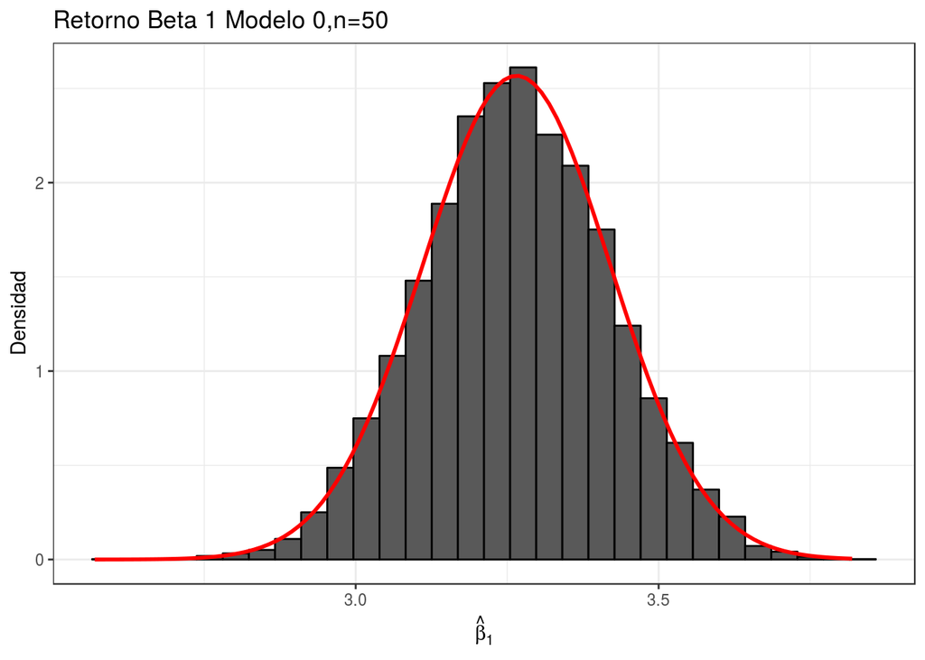

```r
m0_50 = ggplot(betas_df) +
  geom_histogram(aes(betas_df[,5],y=..density..), col="black", bins = 30) +
  stat_function(fun = dnorm, args = list(mean=mean(betas_df[,5]), sd=sd(betas_df[,5])),
                geom = "line", color="red", size=1) +
  ylab("Densidad") + ggtitle("Retorno Beta 1 Modelo 0,n=50") +xlab(expression(hat(beta)[1])) +
  theme_bw()

m0_50
```

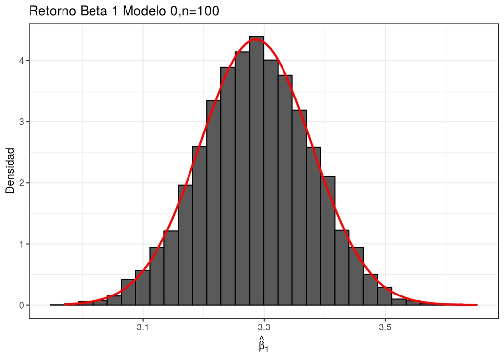

```r
m0_100 = ggplot(betas_df) +
  geom_histogram(aes(betas_df[,6],y=..density..), col="black", bins = 30) +
  stat_function(fun = dnorm, args = list(mean=mean(betas_df[,6]), sd=sd(betas_df[,6])),
                geom = "line", color="red", size=1) +
  ylab("Densidad") + ggtitle("Retorno Beta 1 Modelo 0,n=100") +xlab(expression(hat(beta)[1])) +
  theme_bw()

m0_100
```

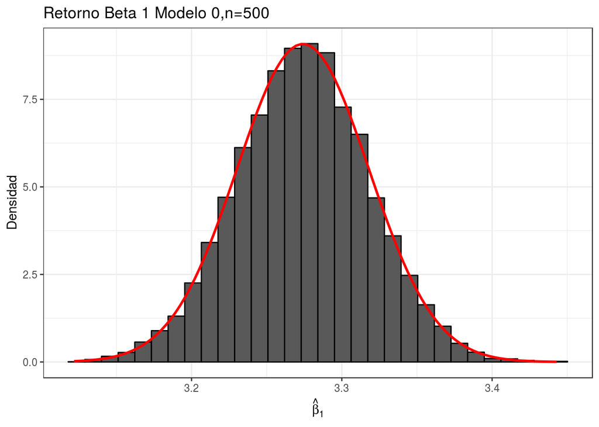

```r
m0_500 = ggplot(betas_df) +
  geom_histogram(aes(betas_df[,7],y=..density..), col="black", bins = 30) +
  stat_function(fun = dnorm, args = list(mean=mean(betas_df[,7]), sd=sd(betas_df[,7])),
                geom = "line", color="red", size=1) +
  ylab("Densidad") + ggtitle("Retorno Beta 1 Modelo 0,n=500") +xlab(expression(hat(beta)[1])) +
  theme_bw()

m0_500
```

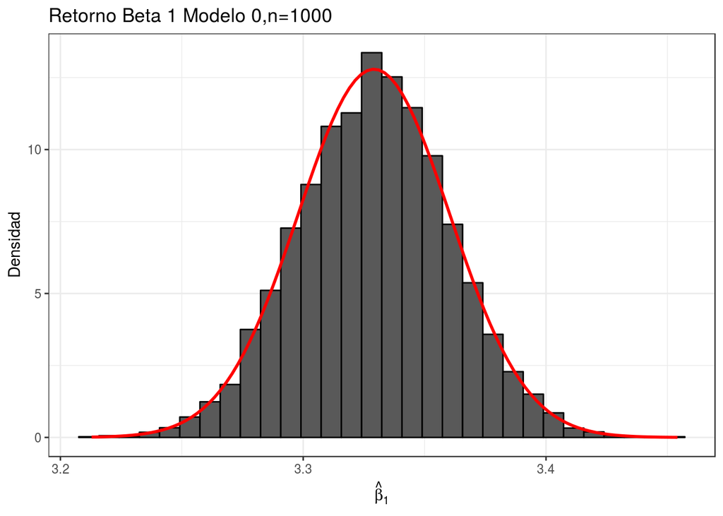

```r
m0_1000 = ggplot(betas_df) +
  geom_histogram(aes(betas_df[,8],y=..density..), col="black", bins = 30) +
  stat_function(fun = dnorm, args = list(mean=mean(betas_df[,8]), sd=sd(betas_df[,8])),
                geom = "line", color="red", size=1) +
  ylab("Densidad") + ggtitle("Retorno Beta 1 Modelo 0,n=1000") +xlab(expression(hat(beta)[1])) +
  theme_bw()

m0_1000
```

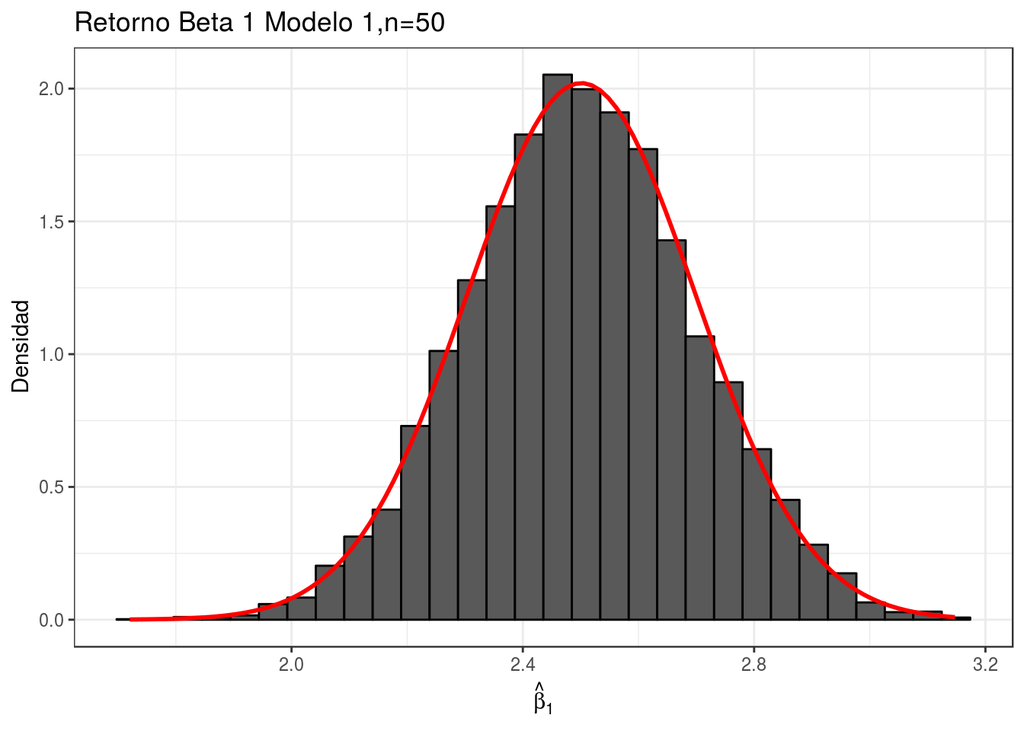

```r
m1_50 = ggplot(betas_df) +
  geom_histogram(aes(betas_df[,13],y=..density..), col="black", bins = 30) +
  stat_function(fun = dnorm, args = list(mean=mean(betas_df[,13]), sd=sd(betas_df[,13])),
                geom = "line", color="red", size=1) +
  ylab("Densidad") + ggtitle("Retorno Beta 1 Modelo 1,n=50") +xlab(expression(hat(beta)[1])) +
  theme_bw()

m1_50
```

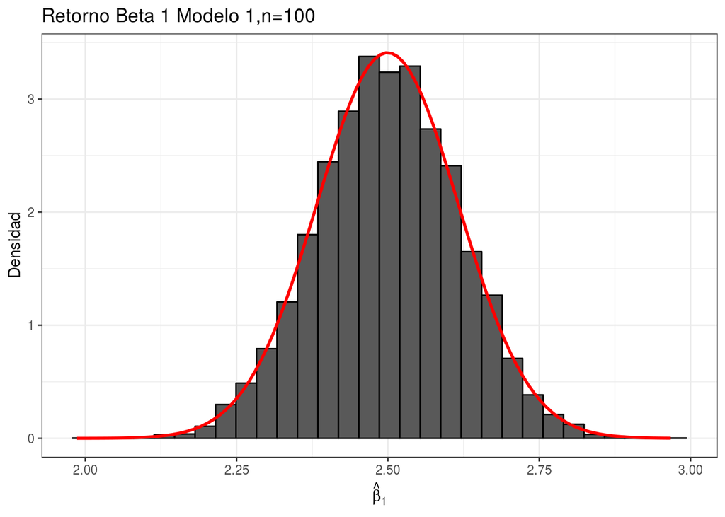

```r
m1_100 = ggplot(betas_df) +
  geom_histogram(aes(betas_df[,14],y=..density..), col="black", bins = 30) +
  stat_function(fun = dnorm, args = list(mean=mean(betas_df[,14]), sd=sd(betas_df[,14])),
                geom = "line", color="red", size=1) +
  ylab("Densidad") + ggtitle("Retorno Beta 1 Modelo 1,n=100") +xlab(expression(hat(beta)[1])) +
  theme_bw()

m1_100
```

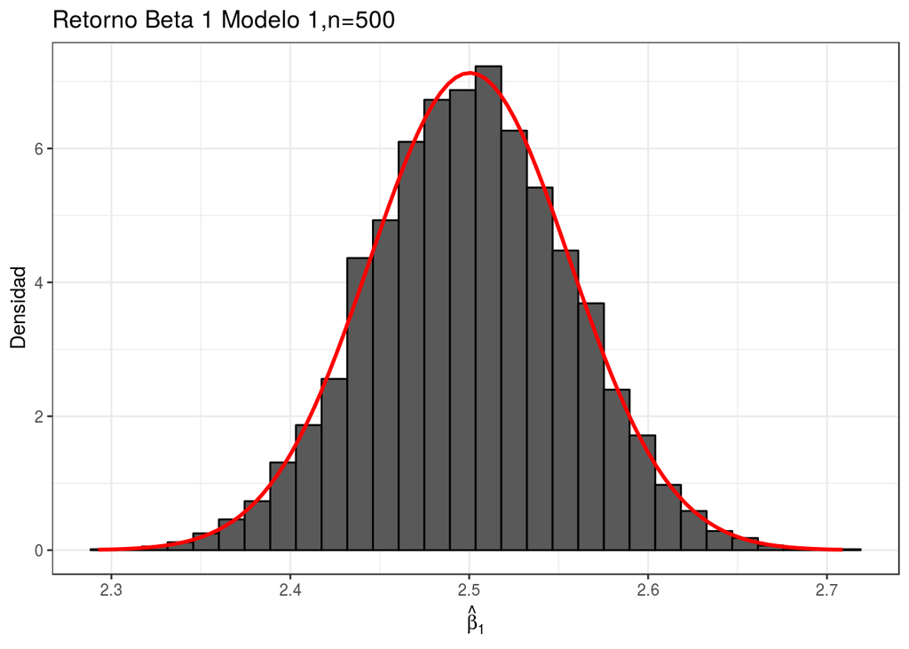

```r
m1_500 = ggplot(betas_df) +
  geom_histogram(aes(betas_df[,15],y=..density..), col="black", bins = 30) +
  stat_function(fun = dnorm, args = list(mean=mean(betas_df[,15]), sd=sd(betas_df[,15])),
                geom = "line", color="red", size=1) +
  ylab("Densidad") + ggtitle("Retorno Beta 1 Modelo 1,n=500") +xlab(expression(hat(beta)[1])) +
  theme_bw()

m1_500
```

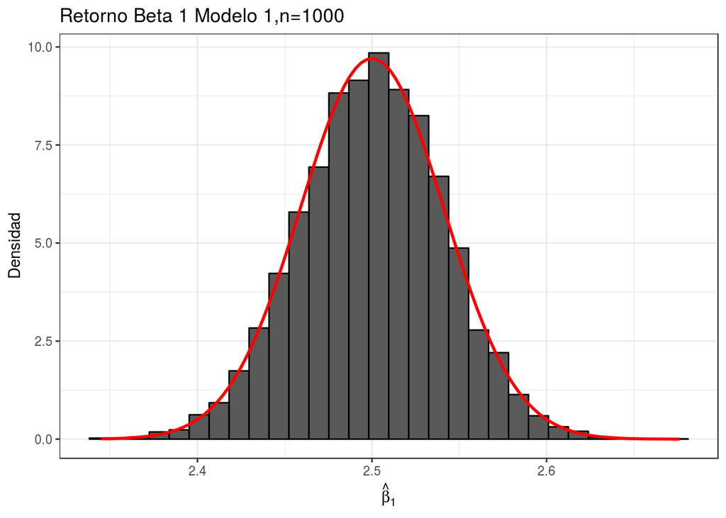

```r
m1_1000 = ggplot(betas_df) +
  geom_histogram(aes(betas_df[,16],y=..density..), col="black", bins = 30) +
  stat_function(fun = dnorm, args = list(mean=mean(betas_df[,16]), sd=sd(betas_df[,16])),
                geom = "line", color="red", size=1) +
  ylab("Densidad") +ggtitle("Retorno Beta 1 Modelo 1,n=1000") +xlab(expression(hat(beta)[1])) +
  theme_bw()

m1_1000
```

### Pregunta c

A continuación se muestran los gráficos para la estimación considerando que x2 se distribuye de manera Uniforme[0.1].

Con la nueva distribucion de X2, b1 si se acerca a su valor verdadero de 2,5. Inluso vemos, en la matriz, que ahora los valores de b1 del modelo erronéo se asimilan mucho a los valores del modelo correcto, para todos los tamaños de la muestra.

En los graficos observamos que la media del coeficiente b1 se encuentra más centrado en 2.5, para todos los tamaños de la muestra.

Es decir, el hecho de que X2 ahora tenga una distribución uniforme 0,1 ayuda a que los valores estimados de los coeficientes se acerquen a su valor verdadero.

```r
betasb = matrix(NA ,nrow = reps, ncol = 16)

for (j in 1:length(n)){
  X1 = rnorm(n[j],20,1)
  X2a = (0.8*X1) + rnorm(n[j],0,1)
  X2b = runif(n[j],0,1)

  for (i in 1:reps) {

    u = rnorm(n[j],0,su)
    v = beta2*X2b + u

    Y0 = beta0 + beta1*X1 + v
    Y1 = beta0 + beta1*X1 + beta2*X2b + u

    model0 = lm(Y0 ~ X1)
    betasb[i,j] = model0$coef[1]
    betasb[i,j+4] = model0$coef[2]

    model1 = lm(Y1 ~ X1 + X2b)
    betasb[i,j+8] = model1$coef[1]
    betasb[i,j+12] = model1$coef[2]
  }
}

betas_dfb = data.frame(betasb)

apply(betas_dfb, 2, mean)
```

```
##       X1       X2       X3       X4       X5       X6       X7       X8
## 2.182596 2.582049 2.427936 2.579636 2.511573 2.494833 2.502298 2.496597
##       X9      X10      X11      X12      X13      X14      X15      X16
## 1.995314 2.023382 1.996468 1.992423 2.500125 2.498937 2.500146 2.500366
```

```r
apply(betas_dfb, 2, var)
```

```
##          X1          X2          X3          X4          X5          X6
## 7.590942603 3.703697430 0.849919185 0.431323879 0.018840371 0.009234041
##          X7          X8          X9         X10         X11         X12
## 0.002101470 0.001074743 7.600877182 3.732038854 0.853140222 0.434447588
##         X13         X14         X15         X16
## 0.018864524 0.009231600 0.002101803 0.001074620
```

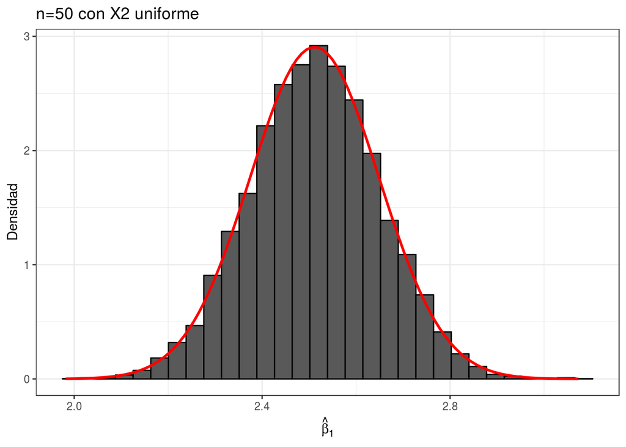

```r
m0_50b = ggplot(betas_dfb) +
  geom_histogram(aes(betas_dfb[,5],y=..density..), col="black", bins = 30) +
  stat_function(fun = dnorm, args = list(mean=mean(betas_dfb[,5]), sd=sd(betas_dfb[,5])),
                geom = "line", color="red", size=1) +
  ylab("Densidad") + ggtitle("n=50 con X2 uniforme") +xlab(expression(hat(beta)[1])) +
  theme_bw()

m0_50b
```

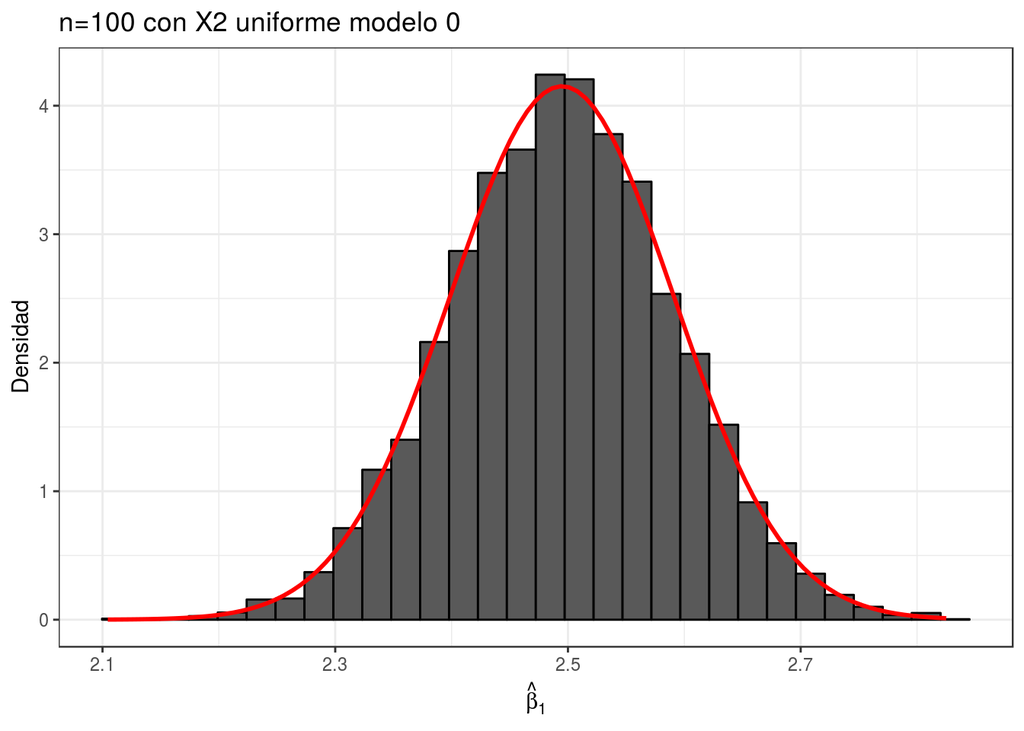

```r
m0_100b = ggplot(betas_dfb) +
  geom_histogram(aes(betas_dfb[,6],y=..density..), col="black", bins = 30) +
  stat_function(fun = dnorm, args = list(mean=mean(betas_dfb[,6]), sd=sd(betas_dfb[,6])),
                geom = "line", color="red", size=1) +
  ylab("Densidad") + ggtitle("n=100 con X2 uniforme modelo 0") +xlab(expression(hat(beta)[1])) +
  theme_bw()

m0_100b
```

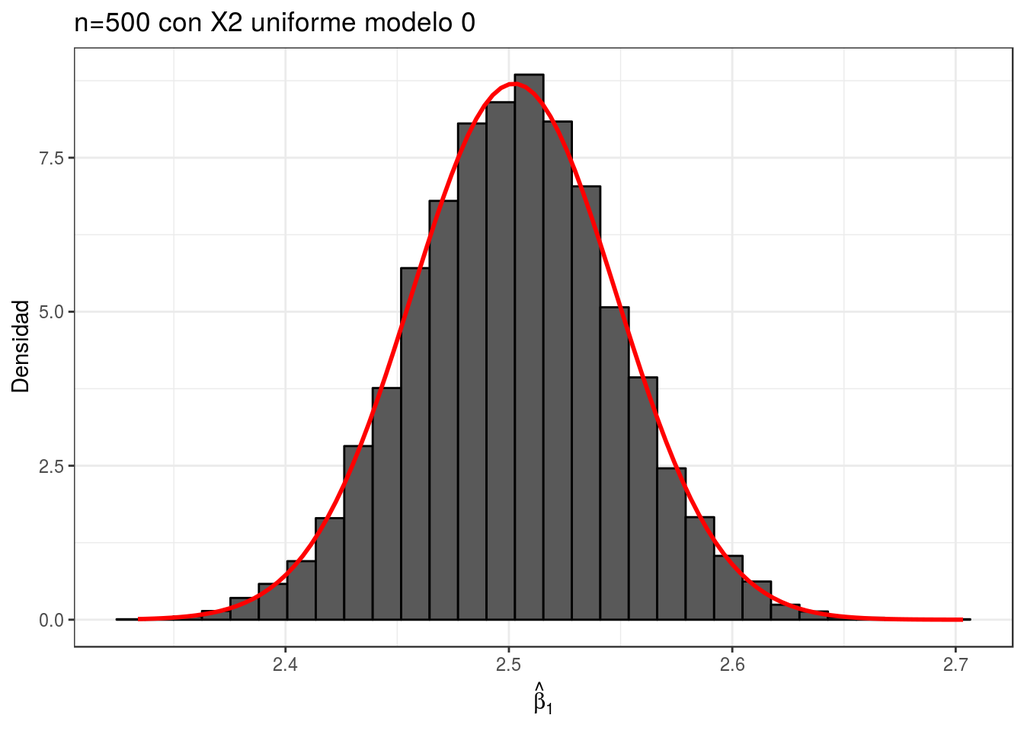

```r
m0_500b = ggplot(betas_dfb) +
  geom_histogram(aes(betas_dfb[,7],y=..density..), col="black", bins = 30) +
  stat_function(fun = dnorm, args = list(mean=mean(betas_dfb[,7]), sd=sd(betas_dfb[,7])),
                geom = "line", color="red", size=1) +
  ylab("Densidad") + ggtitle("n=500 con X2 uniforme modelo 0") +xlab(expression(hat(beta)[1])) +
  theme_bw()

m0_500b
```

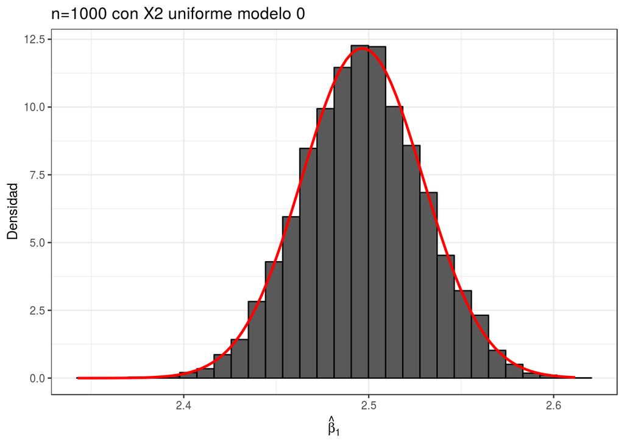

```r
m0_1000b = ggplot(betas_dfb) +
  geom_histogram(aes(betas_dfb[,8],y=..density..), col="black", bins = 30) +
  stat_function(fun = dnorm, args = list(mean=mean(betas_dfb[,8]), sd=sd(betas_dfb[,8])),
                geom = "line", color="red", size=1) +
  ylab("Densidad") + ggtitle("n=1000 con X2 uniforme modelo 0") +xlab(expression(hat(beta)[1])) +
  theme_bw()

m0_1000b
```

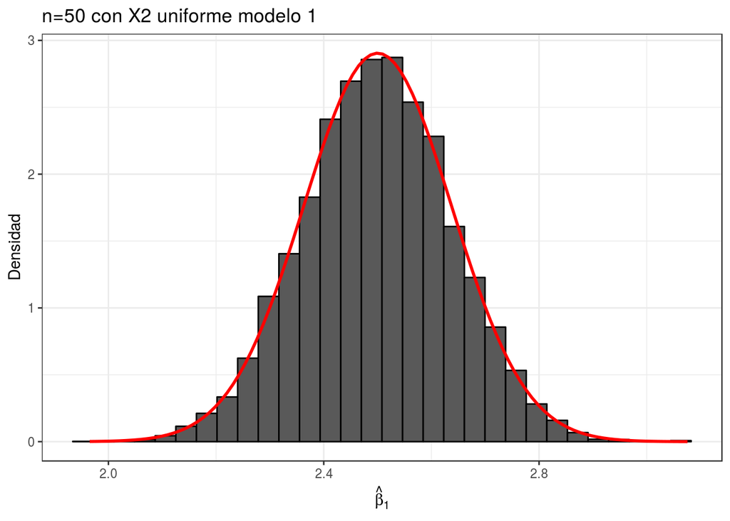

```r
m1_50b = ggplot(betas_dfb) +
  geom_histogram(aes(betas_dfb[,13],y=..density..), col="black", bins = 30) +
  stat_function(fun = dnorm, args = list(mean=mean(betas_dfb[,13]), sd=sd(betas_dfb[,13])),
                geom = "line", color="red", size=1) +
  ylab("Densidad") + ggtitle("n=50 con X2 uniforme modelo 1 ") +xlab(expression(hat(beta)[1])) +
  theme_bw()

m1_50b
```

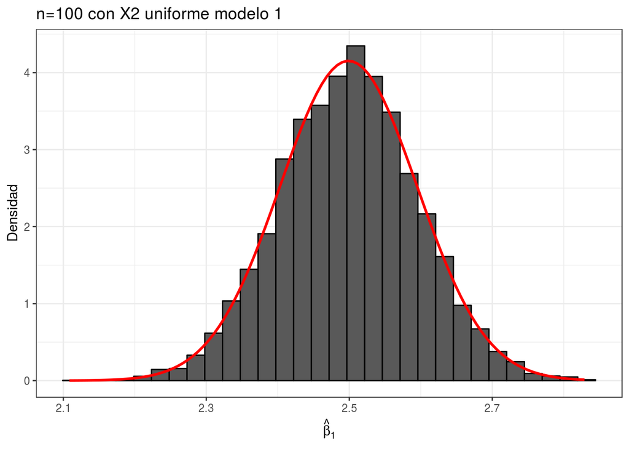

```r
m1_100b = ggplot(betas_dfb) +
  geom_histogram(aes(betas_dfb[,14],y=..density..), col="black", bins = 30) +
  stat_function(fun = dnorm, args = list(mean=mean(betas_dfb[,14]), sd=sd(betas_dfb[,14])),
                geom = "line", color="red", size=1) +
  ylab("Densidad") + ggtitle("n=100 con X2 uniforme modelo 1") +xlab(expression(hat(beta)[1])) +
  theme_bw()

m1_100b
```

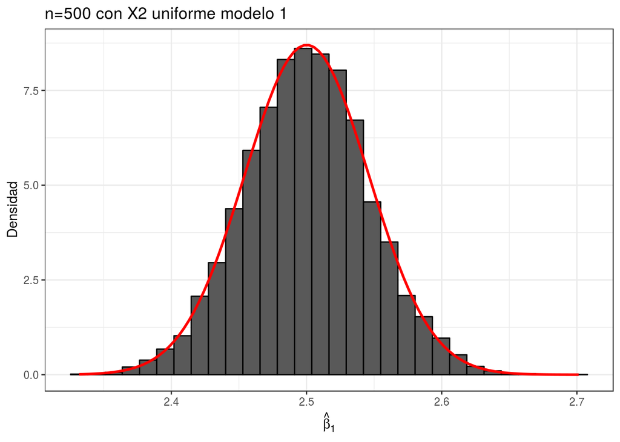

```r
m1_500b = ggplot(betas_dfb) +
  geom_histogram(aes(betas_dfb[,15],y=..density..), col="black", bins = 30) +
  stat_function(fun = dnorm, args = list(mean=mean(betas_dfb[,15]), sd=sd(betas_dfb[,15])),
                geom = "line", color="red", size=1) +
  ylab("Densidad") + ggtitle("n=500 con X2 uniforme modelo 1") +xlab(expression(hat(beta)[1])) +
  theme_bw()

m1_500b
```

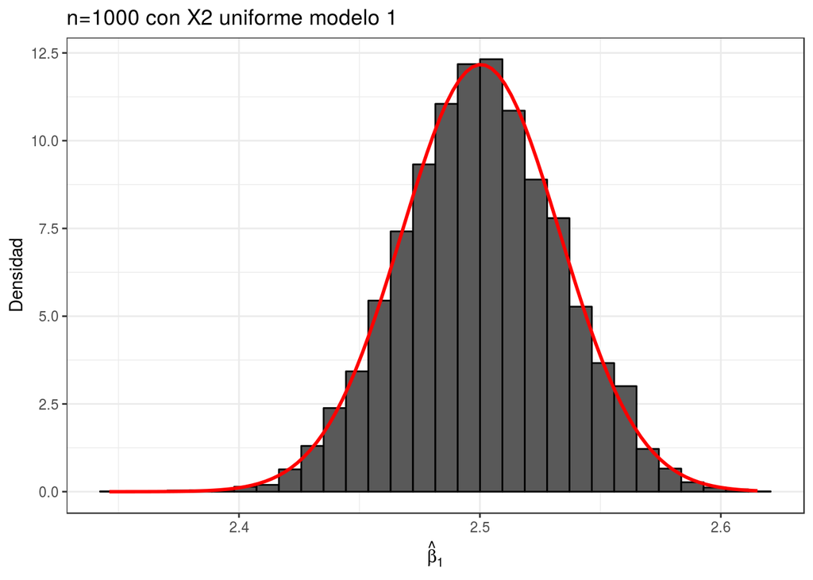

```r
m1_1000b = ggplot(betas_dfb) +
  geom_histogram(aes(betas_dfb[,16],y=..density..), col="black", bins = 30) +
  stat_function(fun = dnorm, args = list(mean=mean(betas_dfb[,16]), sd=sd(betas_dfb[,16])),
                geom = "line", color="red", size=1) +
  ylab("Densidad") + ggtitle("n=1000 con X2 uniforme modelo 1") +xlab(expression(hat(beta)[1])) +
  theme_bw()

m1_1000b
```